# Analise de atividades de parlamentares no Twitter

Mateus de Lima olivera

08 de abril de 2019

```r
twitters = read_csv(here::here("data/atividade-por-perfil-20190322.csv"),
                  col_types = "ccccccddddddddddddd")
glimpse(twitters)
```

```
## Observations: 608
## Variables: 19
## $ id_parlamentar        <chr> "204554", "204521", "204379", "204560", "2…
## $ casa                  <chr> "câmara", "câmara", "câmara", "câmara", "c…
## $ nome_eleitoral        <chr> "ABÍLIO SANTANA", "ABOU ANNI", "ACÁCIO FAV…
## $ partido               <chr> "PR", "PSL", "PROS", "PSDB", "NOVO", "PP",…
## $ UF                    <chr> "BA", "SP", "AP", "BA", "SP", "GO", "MG", …
## $ twitter               <chr> "AbilioSantana_", "abouannipv", "FavachoAc…
## $ seguidores            <dbl> NA, NA, NA, NA, 4652, NA, NA, NA, NA, NA, …
## $ segue                 <dbl> NA, NA, NA, NA, 315, NA, NA, NA, NA, NA, N…
## $ n_proprio             <dbl> 0, 0, 0, 0, 99, 0, 0, 0, 0, 0, 0, 0, NA, 4…
## $ n_retweet             <dbl> 0, 0, 0, 0, 9, 0, 0, 0, 0, 0, 0, 0, NA, 1,…
## $ engaj_total           <dbl> 0, 0, 0, 0, 7090, 0, 0, 0, 0, 0, 0, 0, NA,…
## $ engaj_total_proprio   <dbl> 0, 0, 0, 0, 6701, 0, 0, 0, 0, 0, 0, 0, NA,…
## $ engaj_total_retweet   <dbl> 0, 0, 0, 0, 389, 0, 0, 0, 0, 0, 0, 0, NA, …
## $ engaj_mediano         <dbl> 0.0, 0.0, 0.0, 0.0, 26.5, 0.0, 0.0, 0.0, 0…
## $ engaj_mediano_proprio <dbl> 0.0, 0.0, 0.0, 0.0, 22.5, 0.0, 0.0, 0.0, 0…
## $ engaj_mediano_retweet <dbl> 0.0, 0.0, 0.0, 0.0, 0.0, 0.0, 0.0, 0.0, 0.…
## $ engaj_max             <dbl> 0, 0, 0, 0, 1031, 0, 0, 0, 0, 0, 0, 0, NA,…
## $ engaj_max_proprio     <dbl> 0, 0, 0, 0, 1031, 0, 0, 0, 0, 0, 0, 0, NA,…
## $ engaj_max_retweet     <dbl> 0, 0, 0, 0, 99, 0, 0, 0, 0, 0, 0, 0, NA, 4…
```

### 1 - Quais partidos tem mais engajamento por meio de seus parlamentares?

*- Os principais partidos representantes de ideias divergentes no Brasil, o PT e o PSL, partidos dos ex-vencedores da eleição presidencial e do atual presidente, respectivamente, são os que se destacam em relação aos demais partidos. Isso é meio que intuitivo partindo do ponto de vista que os dois foram os partidos mais votados e comentandos nas últimas eleições, em 2018.*

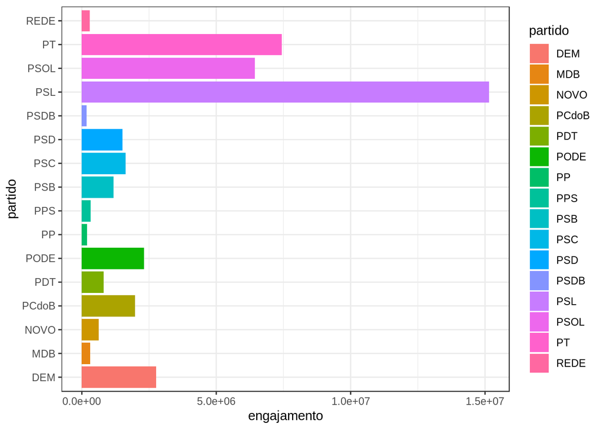

```r
twitters %>%
  filter(!is.na(twitter)) %>%
  group_by(partido) %>%
  summarise(engajamento = sum(engaj_total)) %>%
  filter(engajamento > 100000) %>%
  ggplot(aes(x = partido, y = engajamento, fill = partido))+
  geom_bar(stat='identity') +
  coord_flip()
```

### 1.1 - Dos dois partidos com mais engajamento, quais parlamentares mais se destacam?

*- Existem nomes de cada partido no twitter, onde se destacam os do PSL, que tem engajamento popular maior do que os do segundo colocado entre os partidos populares, o PT.*

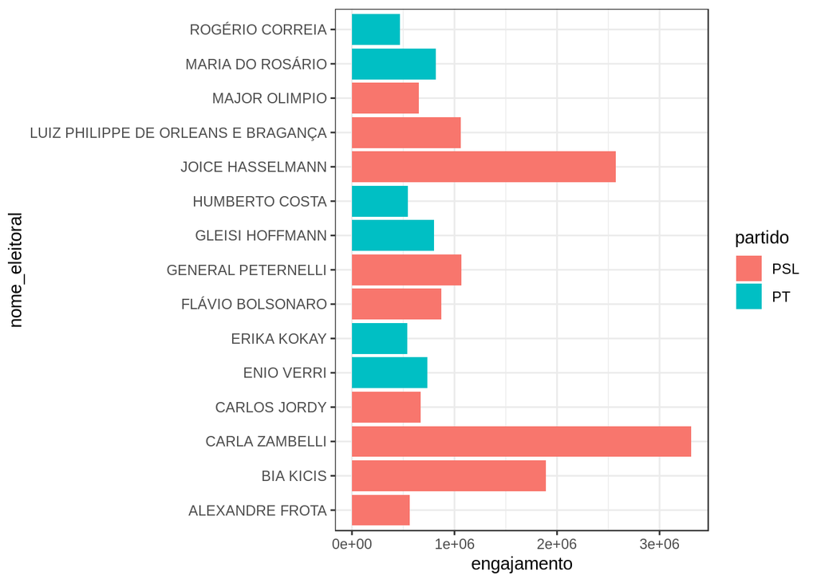

```r
twitters %>%
  filter(!is.na(twitter) & ((partido == "PT" | partido == "PSL"))) %>%
  group_by(nome_eleitoral, partido) %>%
  summarise(engajamento = sum(engaj_total)) %>%
  filter(engajamento > 400000) %>%
  ggplot(aes(x = nome_eleitoral, y = engajamento, fill = partido))+
  geom_bar(stat='identity') +
  coord_flip()
```

### 2 - Parlamentares de qual casa são mais presentes na rede social, percentualmente, com base no numero contas no twittes?

*- Percentualmente, o número de usuarios do twitter no senado é maior em relação à câmara de deputados.*

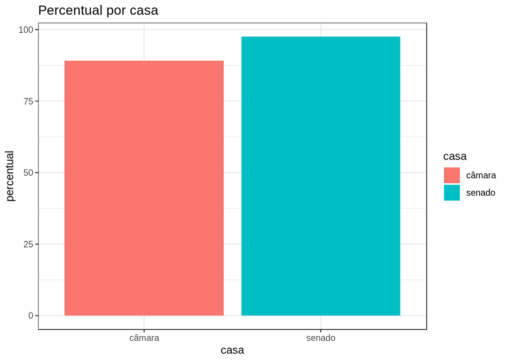

```r
percentual_twitter <- function(casa_parlamentar){
  num_total <- nrow(subset(twitters, casa == casa_parlamentar))
  num_parlamentares_ativos = nrow(subset(twitters, casa == casa_parlamentar & !is.na(twitter)))

  return ((num_parlamentares_ativos/num_total)*100)
}

twitters %>%
  filter(!is.na(twitter) & seguidores > 0) %>%
  group_by(casa) %>%
  summarise(percentual = percentual_twitter(casa)) %>%
  ggplot(aes(x=casa, y=percentual, fill=casa)) +
  geom_bar(stat="identity")+
  labs(
        title="Percentual por casa", x="casa", y="percentual") +
  theme_bw()
```

### 2.1 - Será que a maior presença de senadores, percentualmente, representa maior engajamento, necessariamente?

*- Pode-se verirficar que o engajamento por parte dos deputados é bem maior em relação aos senadores, onde mesmo que em quantidade um pouco menor em numero de contas pelos parlamentares, os deputados são bem mais ativos em suas contas.*

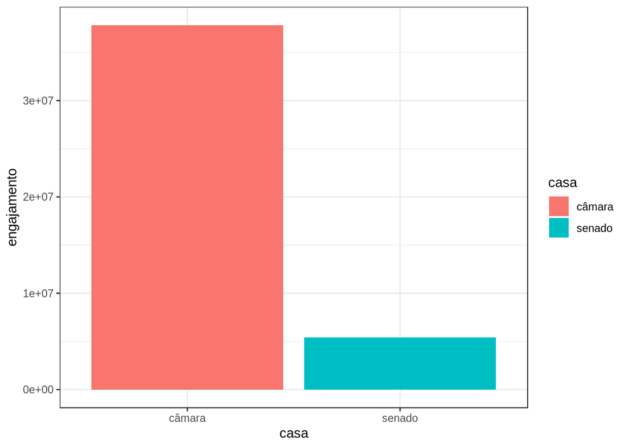

```r
twitters %>%
  filter(!is.na(twitter) & seguidores > 0) %>%
  group_by(casa) %>%
  summarise(engajamento = sum(engaj_total)) %>%
  ggplot(aes(x=casa, y=engajamento, fill=casa)) +
  geom_bar(stat="identity")
```